# COVID-19_analysis

# Introduction

Now we will expand on the lessons from the first part of the workshop and apply the skills we learned to the recent COVID-19 data which has been curated by the Johns Hopkins University Centor fo Systems Science and Engineering (CSSE). We will recreate some of the data they made with their [Tableau dashboard](https://gisanddata.maps.arcgis.com/apps/opsdashboard/index.html#/bda7594740fd40299423467b48e9ecf6) from the [raw data available on Google Sheets](https://docs.google.com/spreadsheets/d/1UF2pSkFTURko2OvfHWWlFpDFAr1UxCBA4JLwlSP6KFo/edit?usp=sharing) or [GitHub](https://github.com/CSSEGISandData/COVID-19). For the purposes of this workshop I took the data from 2020-02-10 and cleaned it (the code used to clean the data is in the 03.Rmd file) so we could focus on learning the concepts.

```r
library(tidyverse)
library(ggsci)
```

```r
data <- read_csv("COVID19.csv")

data
```

| Date | year | month | day | Province | Country | Location | Confirmed_no | Lat | Long |
| --- | --- | --- | --- | --- | --- | --- | --- | --- | --- |
| 2020-01-21 | 2020 | 1 | 21 | Anhui | Mainland China | China | 0 | 31.82571 | 117.22640 |
| 2020-01-22 | 2020 | 1 | 22 | Anhui | Mainland China | China | 1 | 31.82571 | 117.22640 |
| 2020-01-23 | 2020 | 1 | 23 | Anhui | Mainland China | China | 9 | 31.82571 | 117.22640 |
| 2020-01-24 | 2020 | 1 | 24 | Anhui | Mainland China | China | 15 | 31.82571 | 117.22640 |
| 2020-01-25 | 2020 | 1 | 25 | Anhui | Mainland China | China | 60 | 31.82571 | 117.22640 |
| 2020-01-26 | 2020 | 1 | 26 | Anhui | Mainland China | China | 70 | 31.82571 | 117.22640 |
| 2020-01-27 | 2020 | 1 | 27 | Anhui | Mainland China | China | 106 | 31.82571 | 117.22640 |
| 2020-01-28 | 2020 | 1 | 28 | Anhui | Mainland China | China | 152 | 31.82571 | 117.22640 |
| 2020-01-29 | 2020 | 1 | 29 | Anhui | Mainland China | China | 200 | 31.82571 | 117.22640 |
| 2020-01-30 | 2020 | 1 | 30 | Anhui | Mainland China | China | 200 | 31.82571 | 117.22640 |

[output cut: 990 more lines]

```r
data %>%
  glimpse()
```

```
Observations: 1,512
Variables: 10
$ Date         <date> 2020-01-21, 2020-01-22, 2020-01-23, 2020-01-24, 2020-01-25, 2020-01-26, 2020-01-27, 20…
$ year         <dbl> 2020, 2020, 2020, 2020, 2020, 2020, 2020, 2020, 2020, 2020, 2020, 2020, 2020, 2020, 202…
$ month        <dbl> 1, 1, 1, 1, 1, 1, 1, 1, 1, 1, 1, 2, 2, 2, 2, 2, 2, 2, 2, 2, 2, 1, 1, 1, 1, 1, 1, 1, 1, …
$ day          <dbl> 21, 22, 23, 24, 25, 26, 27, 28, 29, 30, 31, 1, 2, 3, 4, 5, 6, 7, 8, 9, 10, 21, 22, 23, …
$ Province     <chr> "Anhui", "Anhui", "Anhui", "Anhui", "Anhui", "Anhui", "Anhui", "Anhui", "Anhui", "Anhui…
$ Country      <chr> "Mainland China", "Mainland China", "Mainland China", "Mainland China", "Mainland China…
$ Location     <chr> "China", "China", "China", "China", "China", "China", "China", "China", "China", "China…
$ Confirmed_no <dbl> 0, 1, 9, 15, 60, 70, 106, 152, 200, 200, 237, 297, 408, 480, 530, 591, 591, 733, 779, 8…
$ Lat          <dbl> 31.82571, 31.82571, 31.82571, 31.82571, 31.82571, 31.82571, 31.82571, 31.82571, 31.8257…
$ Long         <dbl> 117.2264, 117.2264, 117.2264, 117.2264, 117.2264, 117.2264, 117.2264, 117.2264, 117.226…
```

```r
data %>%
  dim()
```

```
[1] 1512   10
```

Let’s try to see if we can aggregate the data similar to the Tableau dashboard. We can use the `group_by()`, `summarize()`, and `arrange()` functions to add up all the confirmed cases by country.

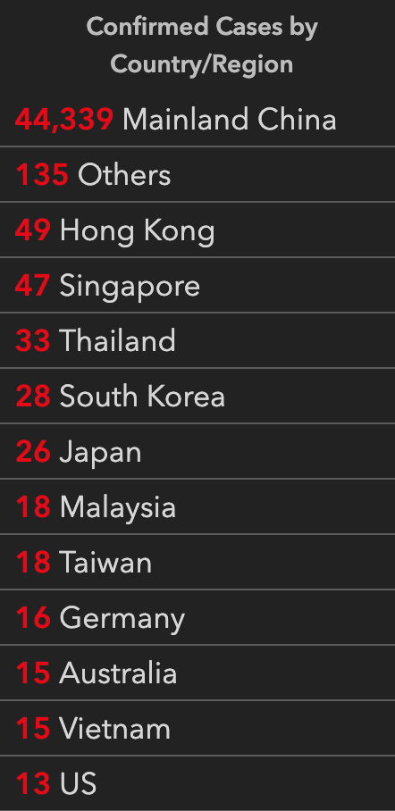

```r
data %>%
  group_by(Country) %>%
  summarize(total = sum(Confirmed_no)) %>%
  arrange(desc(total))
```

| Country | total |
| --- | --- |
| Mainland China | 324613 |
| Thailand | 349 |
| Singapore | 346 |
| Japan | 332 |
| Others | 321 |
| Hong Kong | 297 |
| South Korea | 255 |
| Taiwan | 190 |
| Australia | 176 |
| Malaysia | 163 |

[output cut: 19 more lines]

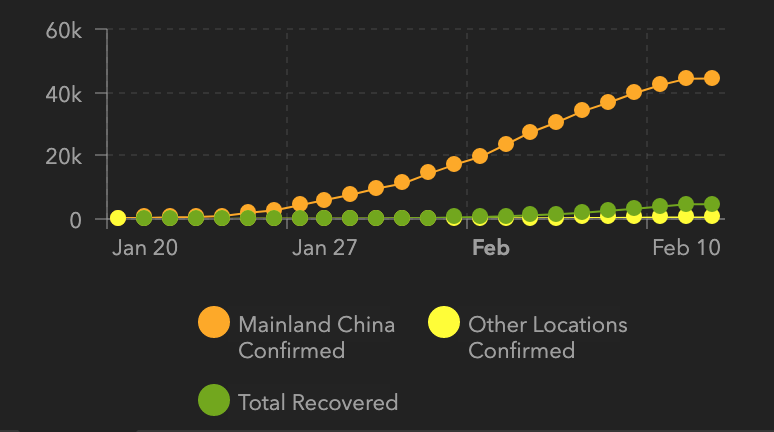

Let’s try to visualize the data! First, we will have to aggregate the data using `group_by()` and `summarize()`.

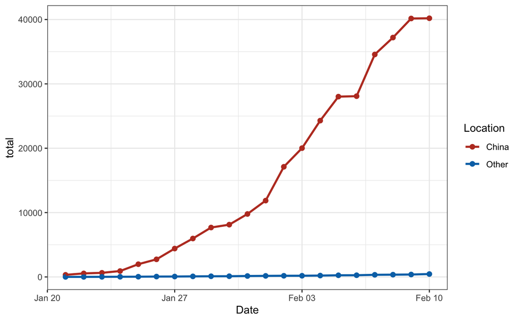

```r
data %>%
  group_by(Location, Date) %>%
  summarize(total = sum(Confirmed_no)) %>%
  ggplot(aes(x = Date, y = total, color = Location)) +
  geom_point(size = 2) +
  geom_line(size = 1) +
  theme_bw() +
  scale_color_nejm()
```

Which Province in China has the most confirmed cases on 2020-02-10?

```r
data
```

[output not shown]